# Regression

Tyler Bontrager, Ganesh Singh

2022-11-18

```r
library(tidyverse)
```

```r
library(ggplot2)
?ggplot2
```

```r
# IMPORTING DATASETS
tuition_cost <- readr::read_csv('https://raw.githubusercontent.com/rfordatascience/tidytuesday/master/data/2020/2020-03-10/tuition_cost.csv')
tc = tuition_cost

tuition_income <- readr::read_csv('https://raw.githubusercontent.com/rfordatascience/tidytuesday/master/data/2020/2020-03-10/tuition_income.csv')
ti = tuition_income

salary_potential <- readr::read_csv('https://raw.githubusercontent.com/rfordatascience/tidytuesday/master/data/2020/2020-03-10/salary_potential.csv')
```

```r
sp = salary_potential

historical_tuition <- readr::read_csv('https://raw.githubusercontent.com/rfordatascience/tidytuesday/master/data/2020/2020-03-10/historical_tuition.csv')
ht = historical_tuition

diversity_school <- readr::read_csv('https://raw.githubusercontent.com/rfordatascience/tidytuesday/master/data/2020/2020-03-10/diversity_school.csv')
ds = diversity_school
```

```r
str(tc)
```

```
## spec_tbl_df [2,973 × 10] (S3: spec_tbl_df/tbl_df/tbl/data.frame)
##  $ name                : chr [1:2973] "Aaniiih Nakoda College" "Abilene Christian University" "Abraham Baldwin Agricultural College" "Academy College" ...
##  $ state               : chr [1:2973] "Montana" "Texas" "Georgia" "Minnesota" ...
##  $ state_code          : chr [1:2973] "MT" "TX" "GA" "MN" ...
##  $ type                : chr [1:2973] "Public" "Private" "Public" "For Profit" ...
##  $ degree_length       : chr [1:2973] "2 Year" "4 Year" "2 Year" "2 Year" ...
##  $ room_and_board      : num [1:2973] NA 10350 8474 NA 16648 ...
##  $ in_state_tuition    : num [1:2973] 2380 34850 4128 17661 27810 ...
##  $ in_state_total      : num [1:2973] 2380 45200 12602 17661 44458 ...
##  $ out_of_state_tuition: num [1:2973] 2380 34850 12550 17661 27810 ...
##  $ out_of_state_total  : num [1:2973] 2380 45200 21024 17661 44458 ...
##  - attr(*, "spec")=
##   .. cols(
##   ..   name = col_character(),
##   ..   state = col_character(),
##   ..   state_code = col_character(),
##   ..   type = col_character(),
##   ..   degree_length = col_character(),
##   ..   room_and_board = col_double(),
##   ..   in_state_tuition = col_double(),
##   ..   in_state_total = col_double(),
##   ..   out_of_state_tuition = col_double(),
##   ..   out_of_state_total = col_double()
##   .. )
##  - attr(*, "problems")=<externalptr>
```

```r
str(ti)
```

```
## spec_tbl_df [209,012 × 7] (S3: spec_tbl_df/tbl_df/tbl/data.frame)
##  $ name       : chr [1:209012] "Piedmont International University" "Piedmont International University" "Piedmont International University" "Piedmont International University" ...
##  $ state      : chr [1:209012] "NC" "NC" "NC" "NC" ...
##  $ total_price: num [1:209012] 20174 20174 20174 20174 20514 ...
##  $ year       : num [1:209012] 2016 2016 2016 2016 2017 ...
##  $ campus     : chr [1:209012] "On Campus" "On Campus" "On Campus" "On Campus" ...
##  $ net_cost   : num [1:209012] 11475 11451 16229 15592 11668 ...
##  $ income_lvl : chr [1:209012] "0 to 30,000" "30,001 to 48,000" "48_001 to 75,000" "75,001 to 110,000" ...
##  - attr(*, "spec")=
##   .. cols(
##   ..   name = col_character(),
##   ..   state = col_character(),
##   ..   total_price = col_double(),
##   ..   year = col_double(),
##   ..   campus = col_character(),
##   ..   net_cost = col_double(),
##   ..   income_lvl = col_character()
##   .. )
##  - attr(*, "problems")=<externalptr>
```

```r
str(sp)
```

```
## spec_tbl_df [935 × 7] (S3: spec_tbl_df/tbl_df/tbl/data.frame)
##  $ rank                     : num [1:935] 1 2 3 4 5 6 7 8 9 10 ...
##  $ name                     : chr [1:935] "Auburn University" "University of Alabama in Huntsville" "The University of Alabama" "Tuskegee University" ...
##  $ state_name               : chr [1:935] "Alabama" "Alabama" "Alabama" "Alabama" ...
##  $ early_career_pay         : num [1:935] 54400 57500 52300 54500 48400 46600 49100 48600 47700 48700 ...
##  $ mid_career_pay           : num [1:935] 104500 103900 97400 93500 90500 ...
##  $ make_world_better_percent: num [1:935] 51 59 50 61 52 53 48 57 56 58 ...
##  $ stem_percent             : num [1:935] 31 45 15 30 3 12 27 17 17 20 ...
##  - attr(*, "spec")=
##   .. cols(
##   ..   rank = col_double(),
##   ..   name = col_character(),
##   ..   state_name = col_character(),
##   ..   early_career_pay = col_double(),
##   ..   mid_career_pay = col_double(),
##   ..   make_world_better_percent = col_double(),
##   ..   stem_percent = col_double()
##   .. )
##  - attr(*, "problems")=<externalptr>
```

```r
str(ht)
```

```
## spec_tbl_df [270 × 4] (S3: spec_tbl_df/tbl_df/tbl/data.frame)
##  $ type        : chr [1:270] "All Institutions" "All Institutions" "All Institutions" "All Institutions" ...
##  $ year        : chr [1:270] "1985-86" "1985-86" "1985-86" "1985-86" ...
##  $ tuition_type: chr [1:270] "All Constant" "4 Year Constant" "2 Year Constant" "All Current" ...
##  $ tuition_cost: num [1:270] 10893 12274 7508 4885 5504 ...
##  - attr(*, "spec")=
##   .. cols(
##   ..   type = col_character(),
##   ..   year = col_character(),
##   ..   tuition_type = col_character(),
##   ..   tuition_cost = col_double()
##   .. )
##  - attr(*, "problems")=<externalptr>
```

```r
str(ds)
```

```
## spec_tbl_df [50,655 × 5] (S3: spec_tbl_df/tbl_df/tbl/data.frame)
##  $ name            : chr [1:50655] "University of Phoenix-Arizona" "University of Phoenix-Arizona" "University of Phoenix-Arizona" "University of Phoenix-Arizona" ...
##  $ total_enrollment: num [1:50655] 195059 195059 195059 195059 195059 ...
##  $ state           : chr [1:50655] "Arizona" "Arizona" "Arizona" "Arizona" ...
##  $ category        : chr [1:50655] "Women" "American Indian / Alaska Native" "Asian" "Black" ...
##  $ enrollment      : num [1:50655] 134722 876 1959 31455 13984 ...
##  - attr(*, "spec")=
##   .. cols(
##   ..   name = col_character(),
##   ..   total_enrollment = col_double(),
##   ..   state = col_character(),
##   ..   category = col_character(),
##   ..   enrollment = col_double()
##   .. )
##  - attr(*, "problems")=<externalptr>
```

```r
tcFactored = tc %>%
  mutate(degFactor = as.factor(degree_length))
tcFactored
```

```
## # A tibble: 2,973 × 11
##    name      state state…¹ type  degre…² room_…³ in_st…⁴ in_st…⁵ out_o…⁶ out_o…⁷
##    <chr>     <chr> <chr>   <chr> <chr>     <dbl>   <dbl>   <dbl>   <dbl>   <dbl>
##  1 Aaniiih … Mont… MT      Publ… 2 Year       NA    2380    2380    2380    2380
##  2 Abilene … Texas TX      Priv… 4 Year    10350   34850   45200   34850   45200
##  3 Abraham … Geor… GA      Publ… 2 Year     8474    4128   12602   12550   21024
##  4 Academy … Minn… MN      For … 2 Year       NA   17661   17661   17661   17661
##  5 Academy … Cali… CA      For … 4 Year    16648   27810   44458   27810   44458
##  6 Adams St… Colo… CO      Publ… 4 Year     8782    9440   18222   20456   29238
##  7 Adelphi … New … NY      Priv… 4 Year    16030   38660   54690   38660   54690
##  8 Adironda… New … NY      Publ… 2 Year    11660    5375   17035    9935   21595
##  9 Adrian C… Mich… MI      Priv… 4 Year    11318   37087   48405   37087   48405
## 10 Advanced… Virg… VA      For … 2 Year       NA   13680   13680   13680   13680
## # … with 2,963 more rows, 1 more variable: degFactor <fct>, and abbreviated
## #   variable names ¹state_code, ²degree_length, ³room_and_board,
## #   ⁴in_state_tuition, ⁵in_state_total, ⁶out_of_state_tuition,
## #   ⁷out_of_state_total
```

```r
tcFacJoinSp = tcFactored %>%
  inner_join(sp, by=c("name"="name"))
tcFacJoinSp
```

```
## # A tibble: 728 × 17
##    name      state state…¹ type  degre…² room_…³ in_st…⁴ in_st…⁵ out_o…⁶ out_o…⁷
##    <chr>     <chr> <chr>   <chr> <chr>     <dbl>   <dbl>   <dbl>   <dbl>   <dbl>
##  1 Adams St… Colo… CO      Publ… 4 Year     8782    9440   18222   20456   29238
##  2 Adventis… Flor… FL      Priv… 4 Year     4200   15150   19350   15150   19350
##  3 Agnes Sc… Geor… GA      Priv… 4 Year    12330   41160   53490   41160   53490
##  4 Alabama … Alab… AL      Publ… 4 Year     5422   11068   16490   19396   24818
##  5 Alaska P… Alas… AK      Priv… 4 Year     7300   20830   28130   20830   28130
##  6 Albany C… New … NY      Priv… 4 Year    10920   35105   46025   35105   46025
##  7 Albertus… Conn… CT      Priv… 4 Year    13200   32060   45260   32060   45260
##  8 Albion C… Mich… MI      Priv… 4 Year    12380   45775   58155   45775   58155
##  9 Alcorn S… Miss… MS      Publ… 4 Year     9608    7144   16752    7144   16752
## 10 Allen Co… Iowa  IA      Priv… 4 Year     7282   19970   27252   19970   27252
## # … with 718 more rows, 7 more variables: degFactor <fct>, rank <dbl>,
## #   state_name <chr>, early_career_pay <dbl>, mid_career_pay <dbl>,
## #   make_world_better_percent <dbl>, stem_percent <dbl>, and abbreviated
## #   variable names ¹state_code, ²degree_length, ³room_and_board,
## #   ⁴in_state_tuition, ⁵in_state_total, ⁶out_of_state_tuition,
## #   ⁷out_of_state_total
```

```r
tcFactored
```

```
## # A tibble: 2,973 × 11
##    name      state state…¹ type  degre…² room_…³ in_st…⁴ in_st…⁵ out_o…⁶ out_o…⁷
##    <chr>     <chr> <chr>   <chr> <chr>     <dbl>   <dbl>   <dbl>   <dbl>   <dbl>
##  1 Aaniiih … Mont… MT      Publ… 2 Year       NA    2380    2380    2380    2380
##  2 Abilene … Texas TX      Priv… 4 Year    10350   34850   45200   34850   45200
##  3 Abraham … Geor… GA      Publ… 2 Year     8474    4128   12602   12550   21024
##  4 Academy … Minn… MN      For … 2 Year       NA   17661   17661   17661   17661
##  5 Academy … Cali… CA      For … 4 Year    16648   27810   44458   27810   44458
##  6 Adams St… Colo… CO      Publ… 4 Year     8782    9440   18222   20456   29238
##  7 Adelphi … New … NY      Priv… 4 Year    16030   38660   54690   38660   54690
##  8 Adironda… New … NY      Publ… 2 Year    11660    5375   17035    9935   21595
##  9 Adrian C… Mich… MI      Priv… 4 Year    11318   37087   48405   37087   48405
## 10 Advanced… Virg… VA      For … 2 Year       NA   13680   13680   13680   13680
## # … with 2,963 more rows, 1 more variable: degFactor <fct>, and abbreviated
## #   variable names ¹state_code, ²degree_length, ³room_and_board,
## #   ⁴in_state_tuition, ⁵in_state_total, ⁶out_of_state_tuition,
## #   ⁷out_of_state_total
```

```r
sp
```

```
## # A tibble: 935 × 7
##     rank name                            state…¹ early…² mid_c…³ make_…⁴ stem_…⁵
##    <dbl> <chr>                           <chr>     <dbl>   <dbl>   <dbl>   <dbl>
##  1     1 Auburn University               Alabama   54400  104500      51      31
##  2     2 University of Alabama in Hunts… Alabama   57500  103900      59      45
##  3     3 The University of Alabama       Alabama   52300   97400      50      15
##  4     4 Tuskegee University             Alabama   54500   93500      61      30
##  5     5 Samford University              Alabama   48400   90500      52       3
##  6     6 Spring Hill College             Alabama   46600   89100      53      12
##  7     7 Birmingham Southern College     Alabama   49100   88300      48      27
##  8     8 University of Alabama at Birmi… Alabama   48600   87200      57      17
##  9     9 University of South Alabama     Alabama   47700   86400      56      17
## 10    10 Alabama A&M University          Alabama   48700   83500      58      20
## # … with 925 more rows, and abbreviated variable names ¹state_name,
## #   ²early_career_pay, ³mid_career_pay, ⁴make_world_better_percent,
## #   ⁵stem_percent
```

```r
tcFacJoinSp
```

```
## # A tibble: 728 × 17
##    name      state state…¹ type  degre…² room_…³ in_st…⁴ in_st…⁵ out_o…⁶ out_o…⁷
##    <chr>     <chr> <chr>   <chr> <chr>     <dbl>   <dbl>   <dbl>   <dbl>   <dbl>
##  1 Adams St… Colo… CO      Publ… 4 Year     8782    9440   18222   20456   29238
##  2 Adventis… Flor… FL      Priv… 4 Year     4200   15150   19350   15150   19350
##  3 Agnes Sc… Geor… GA      Priv… 4 Year    12330   41160   53490   41160   53490
##  4 Alabama … Alab… AL      Publ… 4 Year     5422   11068   16490   19396   24818
##  5 Alaska P… Alas… AK      Priv… 4 Year     7300   20830   28130   20830   28130
##  6 Albany C… New … NY      Priv… 4 Year    10920   35105   46025   35105   46025
##  7 Albertus… Conn… CT      Priv… 4 Year    13200   32060   45260   32060   45260
##  8 Albion C… Mich… MI      Priv… 4 Year    12380   45775   58155   45775   58155
##  9 Alcorn S… Miss… MS      Publ… 4 Year     9608    7144   16752    7144   16752
## 10 Allen Co… Iowa  IA      Priv… 4 Year     7282   19970   27252   19970   27252
## # … with 718 more rows, 7 more variables: degFactor <fct>, rank <dbl>,
## #   state_name <chr>, early_career_pay <dbl>, mid_career_pay <dbl>,
## #   make_world_better_percent <dbl>, stem_percent <dbl>, and abbreviated
## #   variable names ¹state_code, ²degree_length, ³room_and_board,
## #   ⁴in_state_tuition, ⁵in_state_total, ⁶out_of_state_tuition,
## #   ⁷out_of_state_total
```

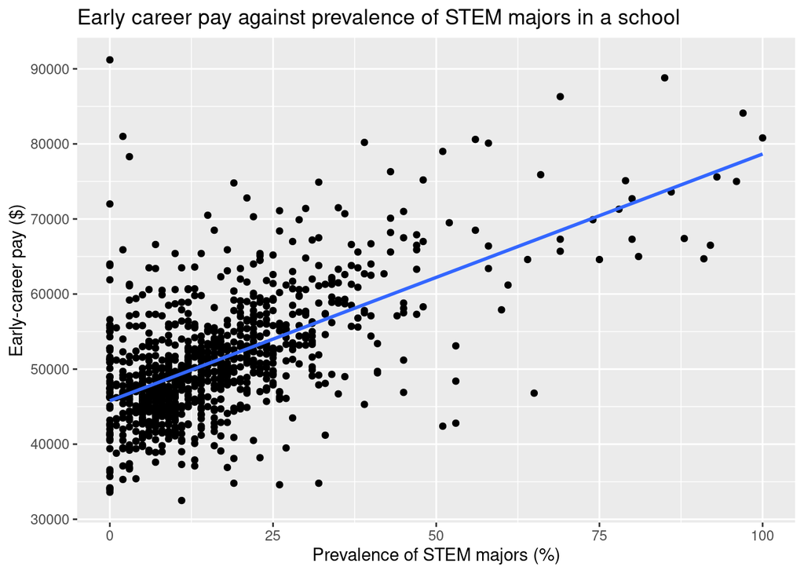

```r
ggplot(sp, aes(stem_percent,early_career_pay)) + geom_point() +
  geom_smooth(method="lm",se=FALSE)+
  ggtitle("Early career pay against prevalence of STEM majors in a school")+
  xlab("Prevalence of STEM majors (%)")+
  ylab("Early-career pay ($)")
```

```r
cor(x=sp$stem_percent,y=sp$early_career_pay)
```

```
## [1] 0.6050609
```

```r
cor(x=sp$stem_percent,y=sp$mid_career_pay)
```

```
## [1] 0.6212143
```

Moderately strong positive association between prevalence of STEM majors at a school and general alumni early-career earnings.

Boring. STEM jobs tend to pay really well. Let’s do something fun. Hear me out…

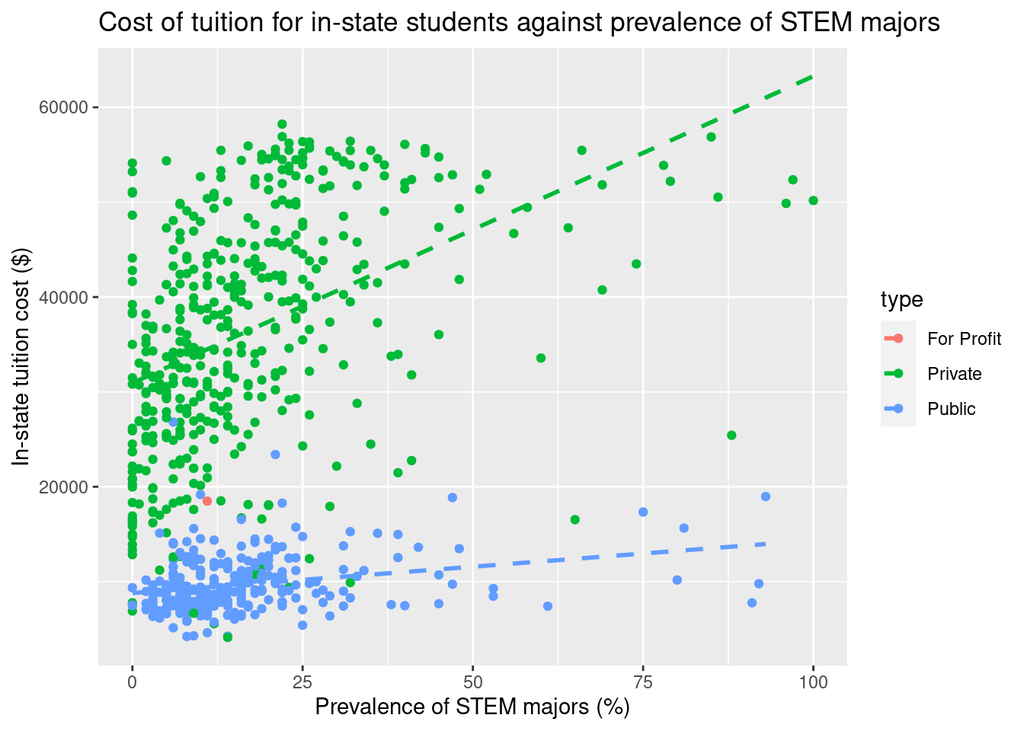

```r
ggplot(tcFacJoinSp, aes(x=stem_percent,y=in_state_tuition,color=type)) +
  geom_point() +
  geom_smooth(method="lm",se=FALSE,lty=2) +
  ggtitle("Cost of tuition for in-state students against prevalence of STEM majors")+
  xlab("Prevalence of STEM majors (%)")+
  ylab("In-state tuition cost ($)")
```

(This graph doesn’t show what was seen first for your convenience, but I will be sure to remove the color for the presentation)

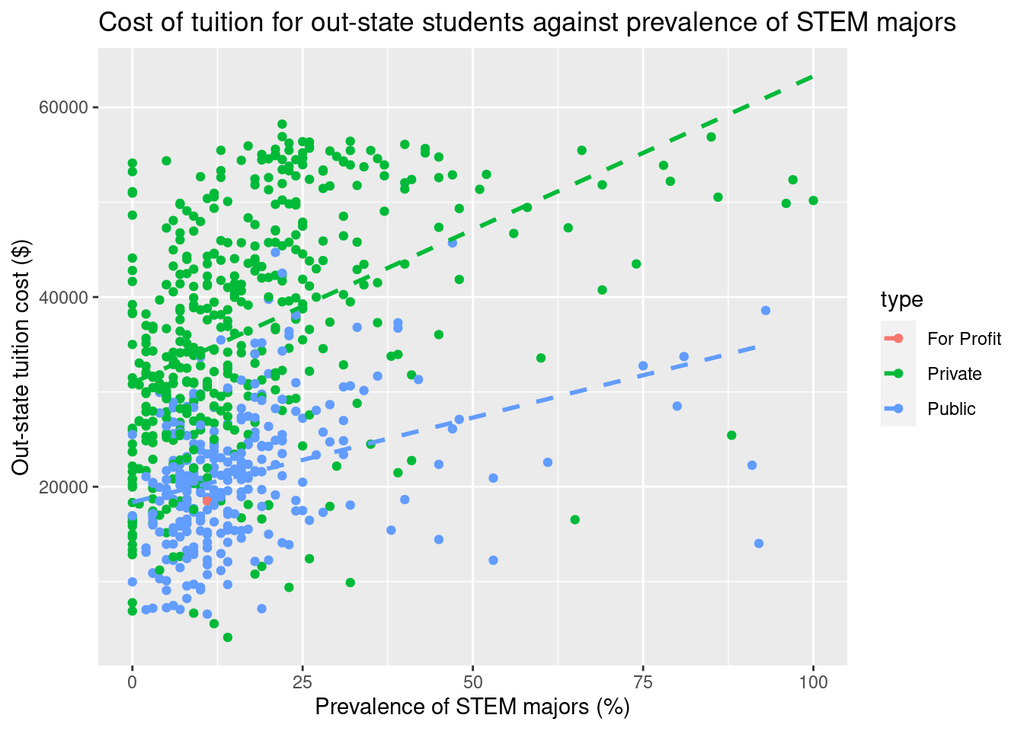

```r
ggplot(tcFacJoinSp, aes(x=stem_percent,y=out_of_state_tuition,color=type)) +
  geom_point() +
  geom_smooth(method="lm",se=FALSE,lty=2) +
  ggtitle("Cost of tuition for out-state students against prevalence of STEM majors")+
  xlab("Prevalence of STEM majors (%)")+
  ylab("Out-state tuition cost ($)")
```

```r
ISSPmodel=lm(in_state_tuition~stem_percent,data=tcFacJoinSp)
OSSPmodel=lm(out_of_state_tuition~stem_percent,data=tcFacJoinSp)

summary(ISSPmodel)
```

```
##
## Call:
## lm(formula = in_state_tuition ~ stem_percent, data = tcFacJoinSp)
##
## Residuals:
##    Min     1Q Median     3Q    Max
## -37716 -15270   1182  13232  32159
##
## Coefficients:
##              Estimate Std. Error t value Pr(>|t|)
## (Intercept)  21958.94     854.44  25.700  < 2e-16 ***
## stem_percent   258.53      37.33   6.926 9.54e-12 ***
## ---
## Signif. codes:  0 '***' 0.001 '**' 0.01 '*' 0.05 '.' 0.1 ' ' 1
##
## Residual standard error: 15790 on 726 degrees of freedom
## Multiple R-squared:  0.06198,    Adjusted R-squared:  0.06069
## F-statistic: 47.97 on 1 and 726 DF,  p-value: 9.539e-12
```

```r
summary(OSSPmodel)
```

```
##
## Call:
## lm(formula = out_of_state_tuition ~ stem_percent, data = tcFacJoinSp)
##
## Residuals:
##    Min     1Q Median     3Q    Max
## -38402  -8987  -1332   9183  28283
##
## Coefficients:
##              Estimate Std. Error t value Pr(>|t|)
## (Intercept)  25835.03     656.62   39.34   <2e-16 ***
## stem_percent   289.00      28.69   10.07   <2e-16 ***
## ---
## Signif. codes:  0 '***' 0.001 '**' 0.01 '*' 0.05 '.' 0.1 ' ' 1
##
## Residual standard error: 12130 on 726 degrees of freedom
## Multiple R-squared:  0.1227, Adjusted R-squared:  0.1215
## F-statistic: 101.5 on 1 and 726 DF,  p-value: < 2.2e-16
```

Notes for story-telling:

Hypothesis: stem_percent high => stem equipment high; cost++?

room and board not considered because r&b charged by a non-academic department, and stem is academic in-state plot revealed cluster out-of-state students do not generally enjoy benefits of tuition discounts at public universities

Hypothesis: public => less burden on student due to public/instate status => generally less tuition, but still guessing stem equipment drives up cost.

```r
cor(tcFacJoinSp$in_state_total,tcFacJoinSp$stem_percent)
```

```
## [1] 0.2781892
```

```r
#duh, cor doesn't care about the clusters.
```

```r
tcFacJoinSpPUB = tcFacJoinSp %>%
  filter(type=="Public")
tcFacJoinSpPUB
```

```
## # A tibble: 276 × 17
##    name      state state…¹ type  degre…² room_…³ in_st…⁴ in_st…⁵ out_o…⁶ out_o…⁷
##    <chr>     <chr> <chr>   <chr> <chr>     <dbl>   <dbl>   <dbl>   <dbl>   <dbl>
##  1 Adams St… Colo… CO      Publ… 4 Year     8782    9440   18222   20456   29238
##  2 Alabama … Alab… AL      Publ… 4 Year     5422   11068   16490   19396   24818
##  3 Alcorn S… Miss… MS      Publ… 4 Year     9608    7144   16752    7144   16752
##  4 Appalach… Nort… NC      Publ… 4 Year     8304    7214   15518   22021   30325
##  5 Arkansas… Arka… AR      Publ… 4 Year     7870    9068   16938   15848   23718
##  6 Armstron… Geor… GA      Publ… 4 Year    11385    6384   17769   19866   31251
##  7 Athens S… Alab… AL      Publ… 4 Year       NA    6810    6810   12870   12870
##  8 Auburn U… Alab… AL      Publ… 4 Year    13332   11276   24608   30524   43856
##  9 Auburn U… Alab… AL      Publ… 4 Year     6980   10288   17268   22048   29028
## 10 Augusta … Geor… GA      Publ… 4 Year     9640   10758   20398   29796   39436
## # … with 266 more rows, 7 more variables: degFactor <fct>, rank <dbl>,
## #   state_name <chr>, early_career_pay <dbl>, mid_career_pay <dbl>,
## #   make_world_better_percent <dbl>, stem_percent <dbl>, and abbreviated
## #   variable names ¹state_code, ²degree_length, ³room_and_board,
## #   ⁴in_state_tuition, ⁵in_state_total, ⁶out_of_state_tuition,
## #   ⁷out_of_state_total
```

```r
tcFacJoinSpPRIV = tcFacJoinSp %>%
  filter(type=="Private")
tcFacJoinSpPRIV
```

```
## # A tibble: 451 × 17
##    name      state state…¹ type  degre…² room_…³ in_st…⁴ in_st…⁵ out_o…⁶ out_o…⁷
##    <chr>     <chr> <chr>   <chr> <chr>     <dbl>   <dbl>   <dbl>   <dbl>   <dbl>
##  1 Adventis… Flor… FL      Priv… 4 Year     4200   15150   19350   15150   19350
##  2 Agnes Sc… Geor… GA      Priv… 4 Year    12330   41160   53490   41160   53490
##  3 Alaska P… Alas… AK      Priv… 4 Year     7300   20830   28130   20830   28130
##  4 Albany C… New … NY      Priv… 4 Year    10920   35105   46025   35105   46025
##  5 Albertus… Conn… CT      Priv… 4 Year    13200   32060   45260   32060   45260
##  6 Albion C… Mich… MI      Priv… 4 Year    12380   45775   58155   45775   58155
##  7 Allen Co… Iowa  IA      Priv… 4 Year     7282   19970   27252   19970   27252
##  8 Alma Col… Mich… MI      Priv… 4 Year    10998   40258   51256   40258   51256
##  9 Amberton… Texas TX      Priv… 4 Year       NA   12840   12840   12840   12840
## 10 Amherst … Mass… MA      Priv… 4 Year    14740   56426   71166   56426   71166
## # … with 441 more rows, 7 more variables: degFactor <fct>, rank <dbl>,
## #   state_name <chr>, early_career_pay <dbl>, mid_career_pay <dbl>,
## #   make_world_better_percent <dbl>, stem_percent <dbl>, and abbreviated
## #   variable names ¹state_code, ²degree_length, ³room_and_board,
## #   ⁴in_state_tuition, ⁵in_state_total, ⁶out_of_state_tuition,
## #   ⁷out_of_state_total
```

```r
cor(tcFacJoinSpPRIV$in_state_tuition,tcFacJoinSpPRIV$stem_percent)
```

```
## [1] 0.4328422
```

```r
cor(tcFacJoinSpPUB$in_state_tuition,tcFacJoinSpPUB$stem_percent)
```

```
## [1] 0.2654226
```

```r
cor(tcFacJoinSpPRIV$out_of_state_tuition,tcFacJoinSpPRIV$stem_percent)
```

```
## [1] 0.4328422
```

```r
cor(tcFacJoinSpPUB$out_of_state_tuition,tcFacJoinSpPUB$stem_percent)
```

```
## [1] 0.3564587
```

Moderately weak positive association between tuition cost and prevalence of stem majors at a school. But only MODERATELY! There still is some good correlation here. Other ideas?

Observation notes:

Correlations for both seem to be generally higher than that of the one taken before splitting.

Question: what is a stronger explanation for expensive schools? Are there other factors beyond funding STEM departments?

This dataset does not contain readily-usable data on ivy-league status or reputation. What if schools use their alumni’s early career salary as a selling point to justify higher prices?